# Assignment 5 - DESeq2

For more detailed instructions, please read the assignment page in the course textbook. Please note that for this assignment, many of the next steps depend on the previous working and for this reason, some of the tests are also dependent on the previous function working correctly. Run your tests one at a time to start, and check that each step is working as expected before moving on.

Use this block to source your `main.R`.

```r
source('main.R')
```

## 1. Reading and subsetting the data from verse_counts.tsv and sample_metadata.csv

To begin, we will subset the counts matrix to only contain a subset of samples found in the original data. We have provided you with the *full* counts matrix of samples and a metadata file containing relevant experimental variables for each sample. These files are named ‘verse_counts.tsv’ and ‘sample_metadata.csv’, respectively. Define a function that reads from these two files to construct a counts matrix and matching sample dataframe containing only samples belonging to the vP0 and vAd timepoints. This should correspond to a total of 4 samples (vP0_1, vP0_2, vAd_1, vAd_2). Store this counts matrix and the sample dataframe in a SummarizedExperiments object. Ensure that the name of your counts matrix stored as an assay in the SummarizedExperiment object is `counts`.

Also check that the order of your samples in your colData is the same as they are ordered in your counts matrix. Before storing your sample dataframe as colData, ensure you set the factor levels so that vP0 is the reference level for the column that will be used as input to the design matrix, in our case, `timepoint`. By default,the first reference level will be considered the reference. Your colData should have columns named `samplename` and `timepoint` as seen in the reference report.

```
## class: SummarizedExperiment
## dim: 55416 4
## metadata(0):
## assays(1): counts
## rownames(55416): ENSMUSG00000102693.2 ENSMUSG00000064842.3 ...
##   ENSMUSG00000095019.2 ENSMUSG00000095041.8
## rowData names(0):
## colnames(4): vP0_1 vP0_2 vAd_1 vAd_2
## colData names(2): samplename timepoint
```

Display the colData from your SummarizedExperiment object here:

```
## DataFrame with 4 rows and 2 columns
##        samplename timepoint
##       <character>  <factor>
## vP0_1       vP0_1       vP0
## vP0_2       vP0_2       vP0
## vAd_1       vAd_1       vAd
## vAd_2       vAd_2       vAd
```

## 2. [Running DESeq2](http://bioconductor.org/packages/devel/bioc/vignettes/DESeq2/inst/doc/DESeq2.html#differential-expression-analysis)

DESeq2 has a built-in function that directly uses a SummarizedExperiment object. Define a function that takes your SummarizedExperiment and a design formula and runs DESeq2 with standard parameters. In our case, we wish to determine what genes are differentially expressed between our samples based on timepoint and our model will simply be `~ timepoint` and we will use `vP0` as our reference level.

Return a *list* containing both the results from DESeq2 as a dataframe as well as the DESeqDataSet object updated with various statistics in the course of the analysis (referred to as the dds in the vignette)

```
## $results_preview
##                        baseMean log2FoldChange    lfcSE        stat    pvalue
## ENSMUSG00000102693.2  0.0000000             NA       NA          NA        NA
## ENSMUSG00000064842.3  0.0000000             NA       NA          NA        NA
## ENSMUSG00000051951.6 12.4786220     -1.3572449 0.961567 -1.41149282 0.1580994
## ENSMUSG00000102851.2  0.0000000             NA       NA          NA        NA
## ENSMUSG00000103377.2  0.4972949      0.4104823 4.845474  0.08471459 0.9324883
## ENSMUSG00000104017.2  0.5984839     -2.4728124 4.860219 -0.50878623 0.6109021
##                           padj
## ENSMUSG00000102693.2        NA
## ENSMUSG00000064842.3        NA
## ENSMUSG00000051951.6 0.3022195
## ENSMUSG00000102851.2        NA
## ENSMUSG00000103377.2        NA
## ENSMUSG00000104017.2        NA
##
## $dispersions_estimated
## [1]        NA        NA 0.3369567        NA 9.3438596
```

## 3. Annotating results to construct a labeled volcano plot

Using the results generated by DESeq2, convert it to a `tibble` and add one additional column that denotes whether a gene is either: 1. Upregulated and significant at a given padj threshold, 2.Downregulated and significant at a given padj threshold, or 3. Not significant at a given padj threshold. **Name this column `volc_plot_status`. Ensure the values for these labels are UP, DOWN, and NS, respectively.** Have your function take the DESeq2 results as well as a user-defined threshold for padj and set it at .10.

```
## Rows: 55,416
## Columns: 8
## $ genes            <chr> "ENSMUSG00000102693.2", "ENSMUSG00000064842.3", "ENSM…
## $ baseMean         <dbl> 0.0000000, 0.0000000, 12.4786220, 0.0000000, 0.497294…
## $ log2FoldChange   <dbl> NA, NA, -1.3572449, NA, 0.4104823, -2.4728124, NA, NA…
## $ lfcSE            <dbl> NA, NA, 0.9615670, NA, 4.8454737, 4.8602188, NA, NA, …
## $ stat             <dbl> NA, NA, -1.41149282, NA, 0.08471459, -0.50878623, NA,…
## $ pvalue           <dbl> NA, NA, 1.580994e-01, NA, 9.324883e-01, 6.109021e-01,…
## $ padj             <dbl> NA, NA, 3.022195e-01, NA, NA, NA, NA, NA, NA, NA, NA,…
## $ volc_plot_status <chr> "NS", "NS", "NS", "NS", "NS", "NS", "NS", "NS", "NS",…
```

### Captions for figures

```r
caption_4 <- 'Histogram showing the raw p-value distribution for all tested genes.'
caption_5 <- 'Histogram of log2 fold changes for genes significant at padj < 0.10.'
caption_6 <- 'Normalized-count jitter plots for the top ten DE genes highlight replicate behavior.'
caption_7 <- 'Volcano plot of log2 fold change vs. -log10(padj) colored by DE status.'
caption_9 <- 'Top pathways with the highest positive and negative normalized enrichment scores.'
```

## 4. Diagnostic plot of the raw p-values for all genes

Using the same results tibble from the previous function, plot a histogram of the raw p-values for all of the genes discovered in the experiment. Avoid using the base ggplot2 theme and make sure to label any appropriate axes and components of the plot.

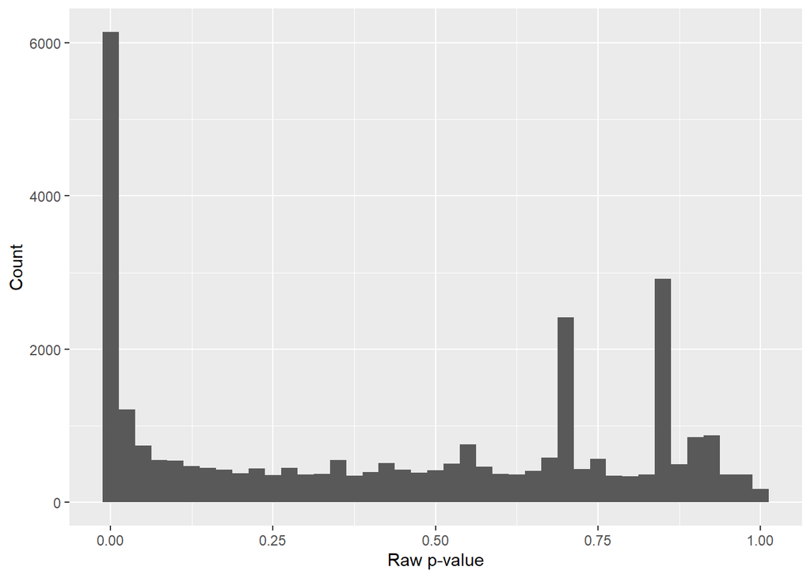

Histogram showing the raw p-value distribution for all tested genes.

## 5. Plotting the LogFoldChanges for differentially expressed genes

Using the results tibble, make a histogram of the Log2FoldChange values for all significant differentially expressed genes at a user-defined padj threshold and set this threshold to .10. Avoid using the base ggplot2 theme and make sure to label any appropriate axes and components of the plot.

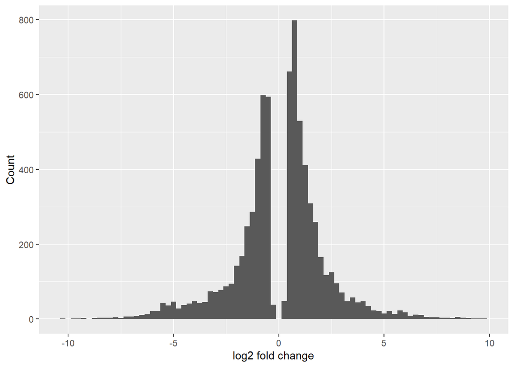

Histogram of log2 fold changes for genes significant at padj < 0.10.

## 6. Plotting the normalized counts of differentially expressed genes

Extract out the DESeq2 normalized counts (by size factors) for the top ten differentially expressed genes as ranked by ascending padj. Make a scatter / jitter plot of the counts and label each by their samplenames.

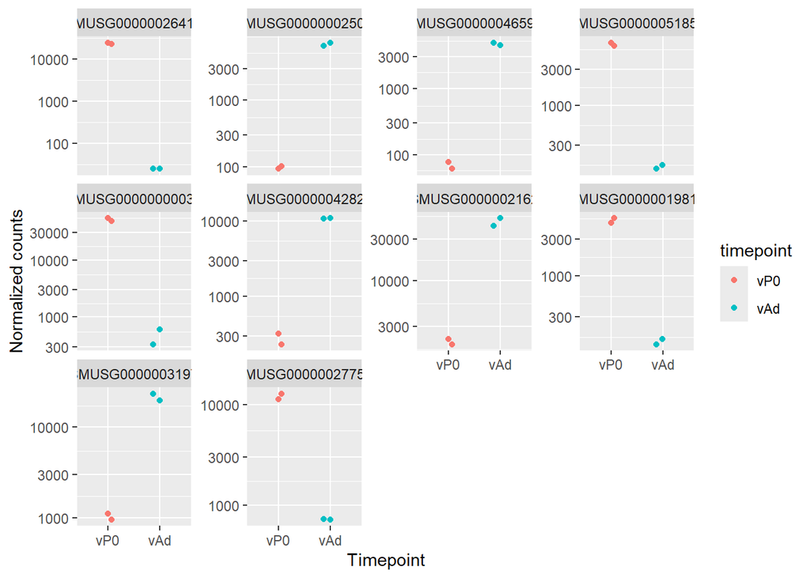

Normalized-count jitter plots for the top ten DE genes highlight replicate behavior.

## 7. Volcano Plot to visualize differential expression results

Using the status column you generated in part 3, make a volcano plot of the DESeq2 results and color the points appropriately.

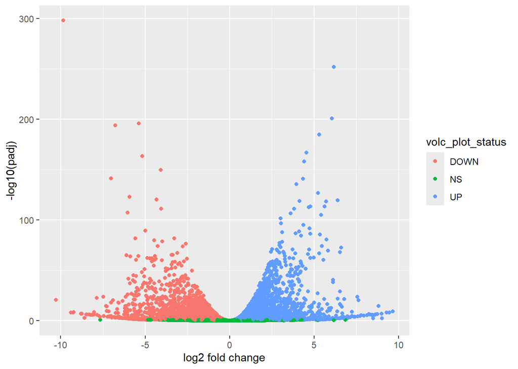

Volcano plot of log2 fold change vs. -log10(padj) colored by DE status.

## 8. Running fgsea

This section will be split into two separate functions that will generated a ranked named list of genes and their log2FoldChange values and perform `fgsea()`, respectively. Please use the provided id2gene.txt file you containing matching ensembl ids and their corresponding gene symbol to add a column to your labeled results for the corresponding gene symbol. Then, use this new column and generate a named vector containing your gene symbols and their corresponding log2FC value ordered by log2FC descending. Make sure to use the gene symbols in place of their ensembl id in order to match the identifiers used in the GMT gene sets file.

```r
#first load in the id2gene.txt appropriately
#add a new column in your labeled results that matches IDs to symbols
#generate a named vector of symbols and log2FC values in descending order
id_map <- readr::read_tsv(
  'data/id2gene.txt',
  col_names = c('gene_id', 'symbol'),
  show_col_types = FALSE
)
labeled_results_symbols <- labeled_results %>%
  dplyr::left_join(id_map, by = c('genes' = 'gene_id')) %>%
  dplyr::mutate(symbol = dplyr::coalesce(symbol, genes))

ranked_log2fc <- make_ranked_log2fc(labeled_results, 'data/id2gene.txt')

dplyr::glimpse(labeled_results_symbols)
```

```
## Rows: 55,416
## Columns: 9
## $ genes            <chr> "ENSMUSG00000102693.2", "ENSMUSG00000064842.3", "ENSM…
## $ baseMean         <dbl> 0.0000000, 0.0000000, 12.4786220, 0.0000000, 0.497294…
## $ log2FoldChange   <dbl> NA, NA, -1.3572449, NA, 0.4104823, -2.4728124, NA, NA…
## $ lfcSE            <dbl> NA, NA, 0.9615670, NA, 4.8454737, 4.8602188, NA, NA, …
## $ stat             <dbl> NA, NA, -1.41149282, NA, 0.08471459, -0.50878623, NA,…
## $ pvalue           <dbl> NA, NA, 1.580994e-01, NA, 9.324883e-01, 6.109021e-01,…
## $ padj             <dbl> NA, NA, 3.022195e-01, NA, NA, NA, NA, NA, NA, NA, NA,…
## $ volc_plot_status <chr> "NS", "NS", "NS", "NS", "NS", "NS", "NS", "NS", "NS",…
## $ symbol           <chr> "4933401J01Rik", "Gm26206", "Xkr4", "Gm18956", "Gm371…
```

```r
#use head to display the top of the list
head(ranked_log2fc, 10)
```

```
##        Strit1          Inmt 2310015A16Rik       Gm49708           Pah
##      9.651319      9.455326      9.298171      9.021722      8.997306
##         mt-Ti       Gm33543        Cxcl14        Retnla      BC023105
##      8.801921      8.736224      8.640420      8.594889      8.498801
```

```r
#use tail to display the bottom of the list
tail(ranked_log2fc, 10)
```

```
##  Rpl17-ps5    Or52ae7        Sln    Slitrk5       Cpa1      Bmp10      Troap
##  -8.462278  -8.470304  -8.586246  -8.762143  -8.798726  -9.230116  -9.251710
##    Or51af1      Tnni1       Dlk1
##  -9.392386  -9.859226 -10.275799
```

Perform a GSEA using a ranked list log2FoldChange values for all genes discovered in the DESeq2 results against the C2 Canonical Pathways gene set collection. As recommended, please set the minSize and maxSize parameters to 15 and 500, respectively. Before running fgsea, you will have to load the GMT pathways file in an appropriate format for `fgsea`. Otherwise, run fgsea using default parameters and the `fgsea()` function.

```
## # A tibble: 10 × 5
##    pathway                                        NES     padj  size leadingEdge
##    <chr>                                        <dbl>    <dbl> <int> <list>
##  1 REACTOME_THE_CITRIC_ACID_TCA_CYCLE_AND_RESP…  2.82 6.64e-20   163 <chr [130]>
##  2 REACTOME_MITOTIC_SPINDLE_CHECKPOINT          -2.73 9.68e-18   107 <chr [32]>
##  3 REACTOME_CELL_CYCLE_CHECKPOINTS              -2.40 1.15e-17   275 <chr [62]>
##  4 REACTOME_AMPLIFICATION_OF_SIGNAL_FROM_THE_K… -2.74 6.34e-17    90 <chr [31]>
##  5 REACTOME_RESOLUTION_OF_SISTER_CHROMATID_COH… -2.65 9.36e-16   116 <chr [36]>
##  6 REACTOME_MITOTIC_PROMETAPHASE                -2.44 2.59e-15   187 <chr [42]>
##  7 REACTOME_MITOTIC_METAPHASE_AND_ANAPHASE      -2.38 3.72e-15   219 <chr [41]>
##  8 REACTOME_RESPIRATORY_ELECTRON_TRANSPORT_ATP…  2.73 4.23e-15   119 <chr [103]>
##  9 REACTOME_RESPIRATORY_ELECTRON_TRANSPORT       2.83 8.44e-15    96 <chr [87]>
## 10 REACTOME_SEPARATION_OF_SISTER_CHROMATIDS     -2.37 1.01e-13   181 <chr [36]>
```

## 9. Plotting the top ten positive NES and top ten negative NES pathways

To make a quick visualization of these GSEA results, make a barchart for the pathways with the top ten most positive and top ten most negative NES scores. Color the bars by whether they have a positive or negative NES.

[figure not shown]

Top pathways with the highest positive and negative normalized enrichment scores.